# Design-Based Inference

Lecture 9B

PUBHBIO 6250

## Fundamental Principle of Probability Sampling

**Probability Sample (“complex surveys”, “sample surveys”)**

Each unit in the population has a known, positive probability of selection, and randomness is involved in the selection of which units are actually included in the sample

We use this fact in **design-based inference**:

- Outcomes $(y)$ measured are **not** **random variables**
  - $y$ does not have a distribution! (hence lowercase)
  - $y_i$s are considered **fixed** (but unknown unless unit $i$ is sampled)
  - Do **not** have to make model assumptions (e.g., $Y \sim$ Normal)
- The random variable is the selection indicator, $Z_i$
  - $Z_i$ = indicator for whether unit $i$ is included in (“selected into”) the sample

## Design-Based Inference

Design-based inference is based on the **distribution of $Z_i$**

- $Z_i$ is binary (0=not selected, 1=selected) $\rightarrow Z_i \sim \text{Bernoulli}(\pi_i)$
- $\pi_i = P($unit $i$ selected into sample$)$
  - Referred to as selection probabilities or inclusion probabilities
- The $\pi_i$s depend on:
  - Population size $N$
  - Sample size $n$
  - Design features used: stratification, clustering, PPS, etc.

Sample designs that use features like clustering, stratification, or PPS usually result in **not all units having the same $\pi_i$**

*(Unequal probability sampling designs/schemes)*

## Example: SRS

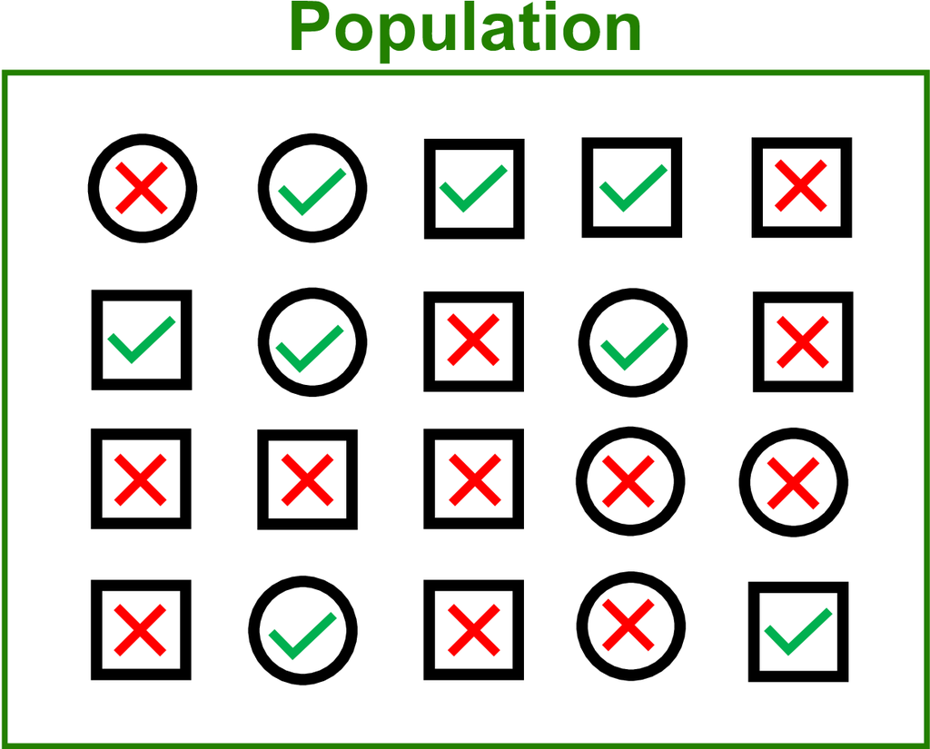

- Small population of $N=20$ units
- Outcome of interest = $y$ = vaccination status ( = vaccinated)
- Parameter of interest = **proportion vaccinated**
- Population truth = $p$ = 8/20 = 0.4
- Individual $y$s (vaccination status) are not random variables – **randomness** comes from the sampling

Random variable: $Z_i = 1$ if unit $i$ is selected into the sample; $Z_i = 0$ if unit $i$ is **not** selected into the sample

## Example: SRS – Repeated Samples

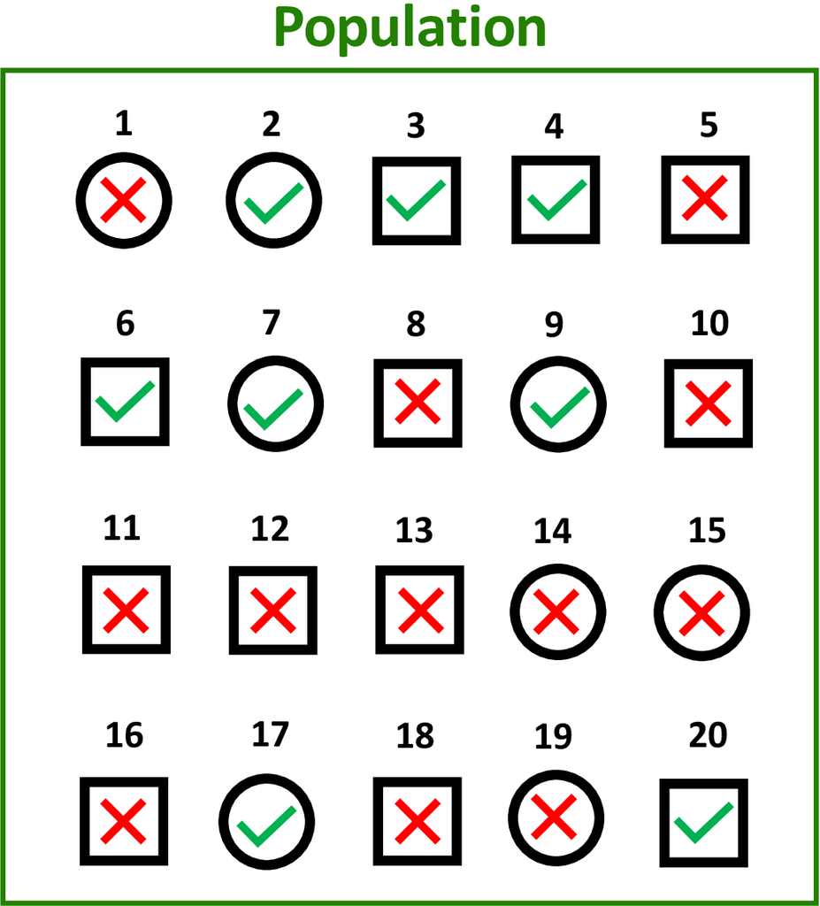

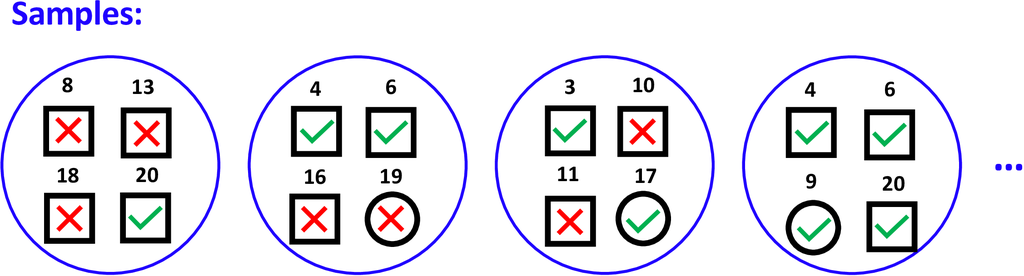

| Unit | S1 $Z_i$ | S2 $Z_i$ | S3 $Z_i$ | S4 $Z_i$ |
| --- | --- | --- | --- | --- |
| 1 | 0 | 0 | 0 | 0 |
| 2 | 0 | 0 | 0 | 0 |
| 3 | 0 | 0 | 1 | 0 |
| 4 | 0 | 1 | 0 | 1 |
| 5 | 0 | 0 | 0 | 0 |
| 6 | 0 | 1 | 0 | 1 |
| 7 | 0 | 0 | 0 | 0 |
| 8 | 1 | 0 | 0 | 0 |
| 9 | 0 | 0 | 0 | 1 |
| 10 | 0 | 0 | 1 | 0 |

| Unit | S1 $Z_i$ | S2 $Z_i$ | S3 $Z_i$ | S4 $Z_i$ |
| --- | --- | --- | --- | --- |
| 11 | 0 | 0 | 1 | 0 |
| 12 | 0 | 0 | 0 | 0 |
| 13 | 1 | 0 | 0 | 0 |
| 14 | 0 | 0 | 0 | 0 |
| 15 | 0 | 0 | 0 | 0 |
| 16 | 0 | 1 | 0 | 0 |
| 17 | 0 | 0 | 1 | 0 |
| 18 | 1 | 0 | 0 | 0 |
| 19 | 0 | 1 | 0 | 0 |
| 20 | 1 | 0 | 0 | 1 |

## Example: SRS – Sample Mean is Unbiased

- Can write the **sample mean** as a function of these $Z_i$ (and $y_i$):

$$\bar{y} = \underbrace{\frac{1}{n} \sum_{i \in \mathcal{S}} y_i}_{\text{sample mean}} = \frac{1}{n}
\bigg\{
\underbrace{\sum_{i \in \mathcal{S}} (1 \times y_i)}_{\text{units in sample}} +
\underbrace{\sum_{i \notin \mathcal{S}} (0 \times y_i)}_{\text{units \textbf{not} in sample}}
\bigg\}
= \frac{1}{n} \underbrace{\sum_{i=1}^N Z_i y_i}_{\text{full pop.}}$$

- Selection indicator $Z_i \sim \text{Bernoulli}(\pi_i)$
  - For an SRS of size $n$ from population of size $N$: $\displaystyle \pi_i = \frac{n}{N}$
  - $\rightarrow E(Z_i) = \pi_i = \frac{n}{N}$
- Thus the expected value of the sample mean over repeated samples is:

$$E(\bar{y}) = E\left(\frac{1}{n} \sum_{i=1}^N Z_i y_i\right) = \frac{1}{n} \sum_{i=1}^N E(Z_i) y_i = \frac{1}{n} \sum_{i=1}^N \frac{n}{N} y_i = \frac{1}{N} \sum_{i=1}^N y_i = \text{pop. mean!}$$

## Example: SRS – Sampling Distribution

Back to the population of $N=20$ units

| Unit | S1 $Z_i$ | S2 $Z_i$ | S3 $Z_i$ | S4 $Z_i$ |
| --- | --- | --- | --- | --- |
| 1 | 0 | 0 | 0 | 0 |
| 2 | 0 | 0 | 0 | 0 |
| 3 | 0 | 0 | 1 | 0 |
| … | … | … | … | … |
| 18 | 1 | 0 | 0 | 0 |
| 19 | 0 | 1 | 0 | 0 |
| 20 | 1 | 0 | 0 | 1 |
| $\hat{p}$: | **0.25** | **0.5** | **0.5** | **1** |

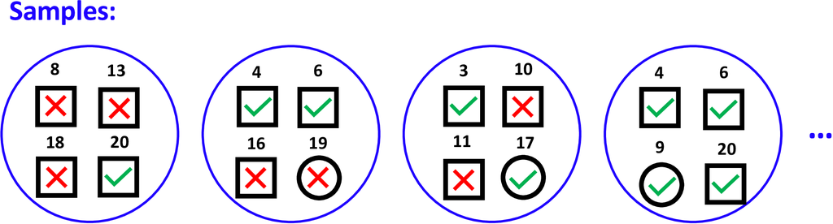

Sampling Distribution:

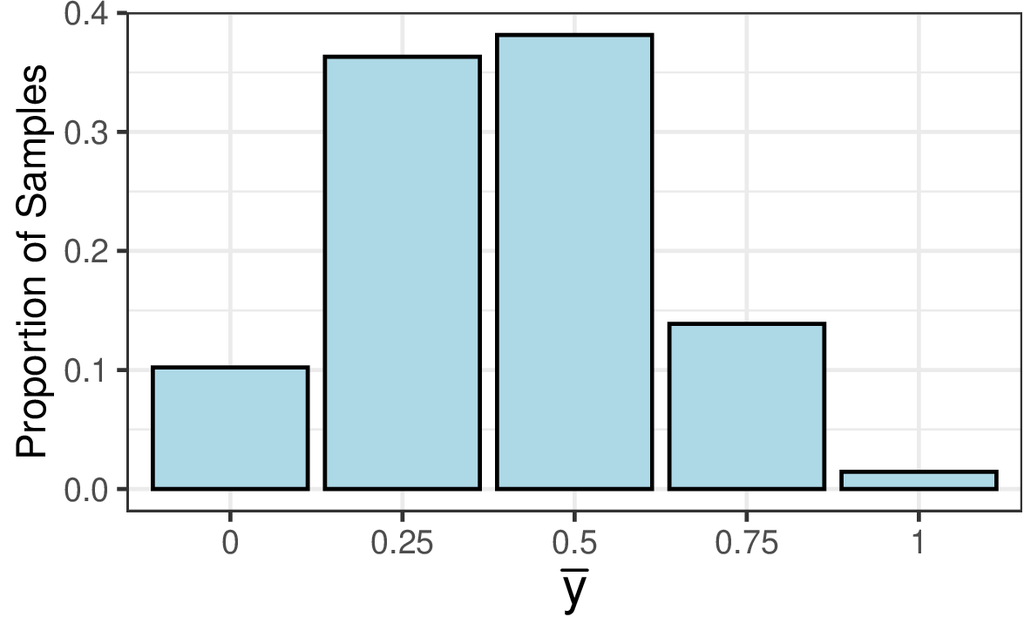

Notice that no sample provides an estimate exactly equal to the population truth ($p=0.4$)!

## Summary

- Traditional survey sampling inference uses **design-based inference**
  - Also called **randomization-based inference**
- **Given a sampling scheme** (that may use complex features like stratification, clustering, PPS, etc.) one could (in theory) list out **all possible samples that could be drawn from the population using this scheme**
- Across these possible samples:
  - Unit $i$’s outcome measurement $(y_i)$ is the same
  - Unit $i$’s selection indicator $(Z_i)$ varies
- The concept of randomness coming entirely from repeated sampling is the basis of **design-based inference** – even though **only one sample will actually be drawn**
- Thus, **the details of the sampling scheme (stratification, clustering, etc.) are critical for inference**